# Матрицы

A. Angelgardt

# Что такое матрица?

> «Увы, невозможно объяснить, что такое матрица. Ты должен увидеть это сам.»  
> *Морфеус (Матрица, 1999)*

Матрица выглядит как таблица чисел, записанных в определенном порядке. Например, вот так:

$$\boldsymbol{A}=
\begin{pmatrix}
1 & 6 & 11 \\
2 & 7 & 13 \\
3 & 8 & 15 \\
4 & 9 & 18 \\
5 & 0 & 19
\end{pmatrix}$$

В данном случае это прямоугольная матрица $\boldsymbol{A}$. Матрицы обозначаются заглавными буквами (иногда еще и полужирным написанием, чтобы отличать от обычных переменных). Количество строк и столбцов определяет размер матрицы. То есть данная матрица имеет размер 5×3 — $\boldsymbol{A}_{5×3}$. При указании размера сначала указывается количество строк, затем — число столбцов.

Ну, и, собственно, всё. Это и есть матрица.

# Откуда берутся матрицы?

Матрицы возникают при решении систем линейных уравнений. Рассмотрим систему.

$$\begin{cases}a_{11}x_1 + a_{12}x_2 + \ldots + a_{1m}x_m = b_1
\\a_{21}x_1 + a_{22}x_2 + \ldots + a_{2m}x_m = b_2
\\ \dots \dots \dots \dots \dots \dots \dots \dots \dots \dots
\\a_{n1}x_1 + a_{n2}x_2 + \ldots + a_{nm}x_m = b_n
\end{cases}$$

Система состоит из $n$ линейных уравнений относительно $m$ неизвестных. Её можно переписать в *матричном виде*:

$$\boldsymbol{A}\boldsymbol{x}= \boldsymbol{b},$$

где

$$\boldsymbol{A}=
\begin{pmatrix}
a_{11} & a_{12} & \dots & a_{1m} \\
a_{21} & a_{22} & \dots & a_{2m} \\
\vdots & \vdots & \ddots & \vdots \\
a_{n1} & a_{n2} & \dots & a_{nm}
\end{pmatrix} ; \quad
\boldsymbol{x}= \begin{pmatrix}
x_1 \\
x_2 \\
\vdots \\
x_m
\end{pmatrix} ; \quad
\boldsymbol{b}= \begin{pmatrix}
b_1 \\
b_2 \\
\vdots \\
b_n
\end{pmatrix}$$

Здесь мы видим матрицу коэффициентов системы $\boldsymbol{A}$. Размер этой матрицы $n × m$. Также мы видим две особых матрицы $\boldsymbol{x}$ и $\boldsymbol{b}$. Количество столбов у них равно единице. Такие матрицы носят название **векторов**.

Но ведь мы можем написать вектор всего с одной строкой. Например, некоторый вектор $\boldsymbol{c}$:

$$\boldsymbol{c}= \begin{pmatrix}
c_1 & c_2 & \dots & c_k
\end{pmatrix}$$

Для большей точности принята следующая терминология: векторы вида $\boldsymbol{x}$ называют «вектор-столбец», а векторы вида $\boldsymbol{c}$ называют «вектор-строка». Векторы часто также обозначаются полужирным начертанием, чтобы отличать их от отдельных значений.

Так как отдельные столбцы матрица мы можем представить в виде векторов, то матрицу $\boldsymbol{A}$ можно написать еще одним способом:
$$\boldsymbol{A}= \begin{pmatrix} \boldsymbol{A}_1 & \boldsymbol{A}_2 & \dots & \boldsymbol{A}_m \end{pmatrix},$$

где

$$\boldsymbol{A}_i = \begin{pmatrix} a_{1i} \\ a_{2i} \\ \vdots \\ a_{ni} \end{pmatrix}, \quad 0<i \leq m$$

Ок, но остается вопрос: почему матричная запись равносильна причной нам записи системы?

**Деталь 1**

Есть две замечательные матрицы: единичная матрица $\boldsymbol{E}$ (иногда $\boldsymbol{I}$) и нулевая матрица $\boldsymbol{O}$:
$$\boldsymbol{E}= \begin{pmatrix}
1 & 0 & \dots & 0 \\
0 & 1 & \dots & 0 \\
\vdots & \vdots & \ddots & \vdots \\
0 & 0 & \dots & 1
\end{pmatrix} ; \quad
\boldsymbol{O}= \begin{pmatrix}
0 & 0 & \dots & 0 \\
0 & 0 & \dots & 0 \\
\vdots & \vdots & \ddots & \vdots \\
0 & 0 & \dots & 0
\end{pmatrix}$$

**Деталь 2**

Матрица размером $n × n$ называется *квадратной матрицей*.

Квадратная матрица, все элементы которой, кроме стоящих на главной диагонали, равны нулю, называется *диагональной матрицей*.

# Действия с матрицами

## Сложение матриц

Сложение определено только для матриц *одинакового размера*.

$$\boldsymbol{A}_{n×m} + \boldsymbol{B}_{n×m} =
\begin{pmatrix}
a_{11} + b_{11} & a_{12} + b_{12} & \dots & a_{1m} + b_{1m} \\
a_{21} + b_{21} & a_{22} + b_{22} & \dots & a_{2m} + b_{2m} \\
\vdots & \vdots & \ddots & \vdots \\
a_{n1} + b_{n1} & a_{n2} + b_{n2} & \dots & a_{nm} + b_{nm}
\end{pmatrix}$$

**Свойства сложения матриц:**

1. $\boldsymbol{A}+ \boldsymbol{B}= \boldsymbol{B}+ \boldsymbol{A}$ (коммутативность)
2. $(\boldsymbol{A}+ \boldsymbol{B}) + \boldsymbol{C}= \boldsymbol{A}+ (\boldsymbol{B}+ \boldsymbol{C})$ (ассоциативность)
3. $\boldsymbol{A}+ \boldsymbol{O}= \boldsymbol{A}$ (существование нулевого элемента)
4. $\boldsymbol{A}+ (-\boldsymbol{A}) = \boldsymbol{O}$ (существование противоположного элемента)

Все, описанное выше, справедливо для векторов.

## Умножение матрицы на число

Умножение на вещественное число определено для любой матрицы $n × m$.

$$\lambda \boldsymbol{A}= \begin{pmatrix}
\lambda a_{11} & \lambda a_{12} & \dots & \lambda a_{1m} \\
\lambda a_{21} & \lambda a_{22} & \dots & \lambda a_{2m} \\
\vdots & \vdots & \ddots & \vdots \\
\lambda a_{n1} & \lambda a_{n2} & \dots & \lambda a_{nm}
\end{pmatrix}, \; \forall \lambda \in \mathbb{R}$$

**Свойства умножения матрицы на число:**

1. $1 \cdot \boldsymbol{A}= \boldsymbol{A}$
2. $-1 \cdot \boldsymbol{A}= -\boldsymbol{A}$
3. $\lambda(\mu \boldsymbol{A}) = (\lambda \mu) \boldsymbol{A}$ (ассоциативность)
4. $(\lambda + \mu) \boldsymbol{A}= \lambda \boldsymbol{A}+ \mu \boldsymbol{A}$ (дистрибутивность)
5. $\lambda (\boldsymbol{A}+ \boldsymbol{B}) = \lambda \boldsymbol{A}+ \lambda \boldsymbol{B}$ (дистрибутивность)

Все, описанное выше, справедливо для векторов.

# Скалярное произведение векторов

Скаларное произведение определено для векторов одинаковой размерности как сумма произведений их соответствующих координат.

$$\boldsymbol{a}= \begin{pmatrix} a_1 & a_2 & \dots & a_n \end{pmatrix} \\
\boldsymbol{b}= \begin{pmatrix} b_1 & b_2 & \dots & b_n \end{pmatrix}\\$$
$$\boldsymbol{a}\cdot \boldsymbol{b}= a_1 b_1 + a_2 b_2 + \dots + a_n b_n$$

# Векторное произведение векторов

> мы рассматривать не будем :)

# Произведение матриц (матричное умножение)

Ну, вот и начался треш.

Умножение определено для матриц $\boldsymbol{A}_{n × k}$ и $\boldsymbol{B}_{k × m}$, то количество столбцов матрицы, стоящей слева от знака умножения, должно быть равно количество строк матрицы, стоящей справа от знака умножения.

Произведением матрицы $\boldsymbol{A}_{n × k}$ на матрицу $\boldsymbol{B}_{k × m}$ называется матрица $\boldsymbol{C}_{n × m}$, элемент которой $c_{ij}$ равен скалярному произведению $i$-го вектора-строки матрицы $\boldsymbol{A}$ и $j$-го вектора-столбца матрицы $\boldsymbol{B}$.

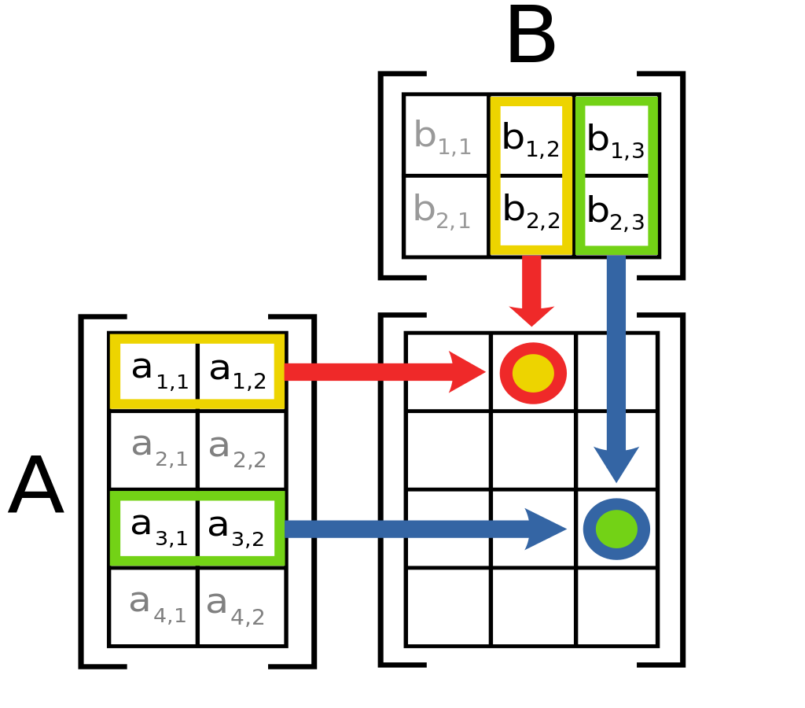

Пусть
$$\boldsymbol{A}=
\begin{pmatrix}
\boldsymbol{a}_1 \\
\boldsymbol{a}_2 \\
\vdots \\
\boldsymbol{a}_n
\end{pmatrix} =
\begin{pmatrix}
a_{11} & a_{12} & \dots & a_{1k} \\
a_{21} & a_{22} & \dots & a_{2k} \\
\vdots & \vdots & \ddots & \vdots \\
a_{n1} & a_{n2} & \dots & a_{nk}
\end{pmatrix}, \\
\boldsymbol{B}=
\begin{pmatrix}
\boldsymbol{b}_1 & \boldsymbol{b}_2 & \dots \boldsymbol{b}_m
\end{pmatrix} =
\begin{pmatrix}
b_{11} & b_{12} & \dots & b_{1m} \\
b_{21} & b_{22} & \dots & b_{2m} \\
\vdots & \vdots & \ddots & \vdots \\
b_{k1} & b_{k2} & \dots & b_{km}
\end{pmatrix}$$

Тогда,

$$\boldsymbol{A}\times \boldsymbol{B}=
\begin{pmatrix}
\boldsymbol{a}_1 \cdot \boldsymbol{b}_1 & \boldsymbol{a}_1 \cdot \boldsymbol{b}_2 & \dots & \boldsymbol{a}_1 \cdot \boldsymbol{b}_m \\
\boldsymbol{a}_2 \cdot \boldsymbol{b}_1 & \boldsymbol{a}_2 \cdot \boldsymbol{b}_2 & \dots & \boldsymbol{a}_2 \cdot \boldsymbol{b}_m \\
\vdots & \vdots & \ddots & \vdots \\
\boldsymbol{a}_n \cdot \boldsymbol{b}_1 & \boldsymbol{a}_n \cdot \boldsymbol{b}_2 & \dots & \boldsymbol{a}_n \cdot \boldsymbol{b}_m \\
\end{pmatrix} = \\ =
\begin{pmatrix}
(a_{11} b_{11} + a_{12} b_{21} + \dots + a_{1k}b_{k1}) & (a_{11} b_{12} + a_{12} b_{22} + \dots + a_{1k}b_{k2}) & \dots & (a_{11} b_{1m} + a_{12} b_{2m} + \dots + a_{1k}b_{km}) \\
(a_{21} b_{11} + a_{22} b_{21} + \dots + a_{2k}b_{k1}) & (a_{21} b_{12} + a_{22} b_{22} + \dots + a_{2k}b_{k2}) & \dots & (a_{21} b_{1m} + a_{22} b_{2m} + \dots + a_{2k}b_{km}) \\
\vdots & \vdots & \ddots & \vdots \\
(a_{n1} b_{11} + a_{n2} b_{21} + \dots + a_{nk}b_{k1}) & (a_{n1} b_{12} + a_{n2} b_{22} + \dots + a_{nk}b_{k2}) & \dots & (a_{n1} b_{1m} + a_{n2} b_{2m} + \dots + a_{nk}b_{km})
\end{pmatrix} = \\ =
\begin{pmatrix}
c_{11} & c_{12} & \dots & c_{1m} \\
c_{21} & c_{22} & \dots & c_{2m} \\
\vdots & \vdots & \ddots & \vdots \\
c_{n1} & c_{n2} & \dots & c_{nm}
\end{pmatrix} = \boldsymbol{C}$$

$$c_{ij} = \sum_{t=1}^k a_{it} b_{tj}$$

Вот так вот.

**Cвойства произведения матриц:**

1. $\boldsymbol{A}(\boldsymbol{B}\boldsymbol{C}) = (\boldsymbol{A}\boldsymbol{B}) \boldsymbol{C}$ (ассоциативность)
2. $\lambda (\boldsymbol{A}\boldsymbol{B}) = (\lambda \boldsymbol{A}) \boldsymbol{B}= (\lambda \boldsymbol{B}) \boldsymbol{A}$ (ассоциативность)
3. $\boldsymbol{A}(\boldsymbol{B}+ \boldsymbol{C}) = \boldsymbol{A}\boldsymbol{B}+ \boldsymbol{A}\boldsymbol{C}$ (дистрибутивность)
4. $(\boldsymbol{A}+ \boldsymbol{B}) \boldsymbol{C}= \boldsymbol{A}\boldsymbol{C}+ \boldsymbol{B}\boldsymbol{C}$ (дистрибутивность)
5. $\boldsymbol{A}\boldsymbol{B}\neq \boldsymbol{B}\boldsymbol{A}$ (отсутствие коммутативности)
6. $\boldsymbol{E}\boldsymbol{A}= \boldsymbol{A}; \, \boldsymbol{A}\boldsymbol{E}= \boldsymbol{A}$ (умножение на единичный элемент)
7. $\boldsymbol{O}\boldsymbol{A}= \boldsymbol{O}; \, \boldsymbol{A}\boldsymbol{O}= \boldsymbol{O}$ (умножение на нулевой элемент)
8. $\boldsymbol{A}\boldsymbol{A}^{-1} = \boldsymbol{A}^{-1} \boldsymbol{A}= \boldsymbol{E}$ (умножение на обратную матрицу — *только для некоторых квадратных матриц*)

Матричное умножение определено для векторов-столбцов (матриц-столбцов) и векторов-строк (матриц-строк) и выполняется по тем же правилам.

## Транспонирование матрицы

В матрице строки и столбцы можно поменять местами — получится транспонированная матрица.

$$\boldsymbol{A}=
\begin{pmatrix}
\boldsymbol{a}_1 \\
\boldsymbol{a}_2 \\
\vdots \\
\boldsymbol{a}_n
\end{pmatrix} =
\begin{pmatrix}
a_{11} & a_{12} & \dots & a_{1k} \\
a_{21} & a_{22} & \dots & a_{2k} \\
\vdots & \vdots & \ddots & \vdots \\
a_{n1} & a_{n2} & \dots & a_{nk}
\end{pmatrix}$$
$$\boldsymbol{A}^\mathrm{T}=
\begin{pmatrix}
\boldsymbol{a}_1 & \boldsymbol{a}_2 & \dots & \boldsymbol{a}_n
\end{pmatrix} =
\begin{pmatrix}
a_{11} & a_{21} & \dots & a_{n1} \\
a_{12} & a_{22} & \dots & a_{n2} \\
\vdots & \vdots & \ddots & \vdots \\
a_{1k} & a_{2k} & \dots & a_{nk}
\end{pmatrix}$$
Транспонированная матрица будем иметь размер $k × n$.

# Задание

Дано:
$$\boldsymbol{A}=
\begin{pmatrix}
1 & 3 \\
2 & 4
\end{pmatrix} , \quad
\boldsymbol{B}=
\begin{pmatrix}
5 & 6 & 7 \\
8 & 9 & 0
\end{pmatrix} , \\
\boldsymbol{a}=
\begin{pmatrix}
11 & 22 & 33
\end{pmatrix}, \quad
\boldsymbol{b}=
\begin{pmatrix}
101 \\
102 \\
103
\end{pmatrix}.$$

Вычислить:

1. $\boldsymbol{A}\times \boldsymbol{B}$
2. $\boldsymbol{B}\times \boldsymbol{A}$
3. $\boldsymbol{a}\times \boldsymbol{b}$
4. $\boldsymbol{b}\times \boldsymbol{a}$
5. $\boldsymbol{a}\times \boldsymbol{a}^\mathrm{T}$

Чтобы проверить ответ, введите в соответствующее поле значения элементов матрицы построчно. Элементы одной строки разделяйте пробелами, строки разделяйте запятыми.

[figure not shown]